### Dimension Reduction

13. For the PCA of `census.ct` and `census.subct`, I choose to center and scale the features. Because the some of the variables are with different units than percentage. And the scale effects the PCA results. Therefore it’s better to scale the features.  
    By `View()` the rotation matrix of the PCA report we can see that for `ct.pc`, the features with largest absolute values for PC1 are `IncomePerCap`, `ChildPoverty` and `Poverty`, and `IncomePerCap` has opposite signs against the other two features. For `subct.pc`, the features with largest absolute values for PC1 are `IncomePerCap`, `Professional` and `ChildPoverty`. Similarly, `ChildPoverty` has an opposite sign against the other two features. This means that these features affects the PC1 the most, but opposite sign implies that they lead PC1 to opposite directions.
14. The plots of PVE and cumulative PVE are shown below. And the minimum number of PCs needed to capture 90% of the variance for both of analysis is 15.

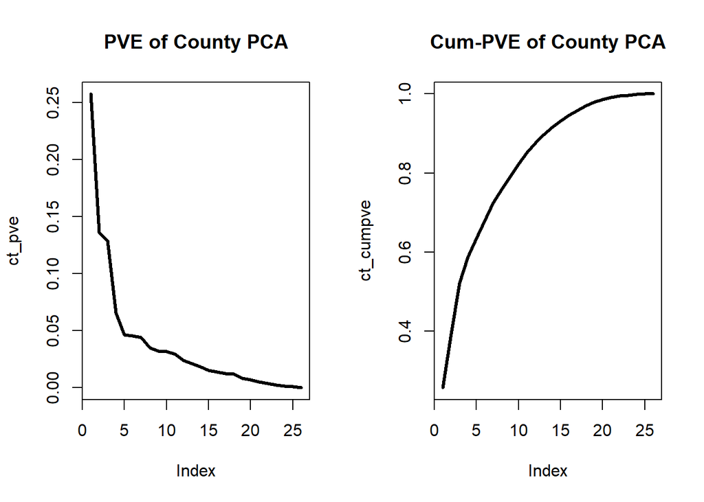

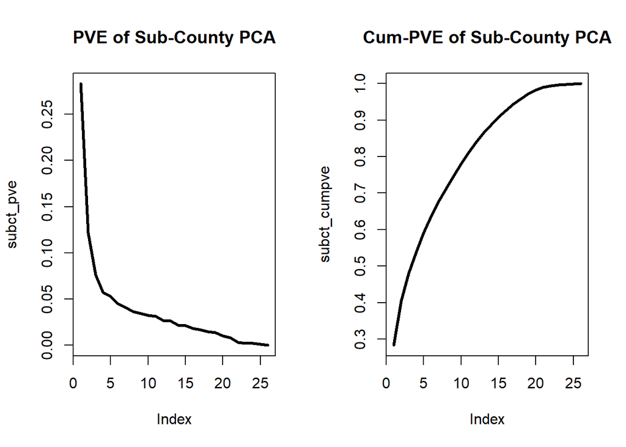

### Clustering

15. From our clustering results, we found that San Mateo County is in cluster 2 for the original features clustering, but in cluster 7 in the first 5 PCs clustering. I think the clustering using the first 5 PCs is an more appropriate approach. Since the data were scaled at the beginning. And as we can see in the table of the number of counties in each cluster for the two clustering methods, we observe a more evenly split clusters in clustering with first 5 PCs than original features. So it is the more appropriate approach.

```
## ct.clus
##    1    2    3    4    5    6    7    8    9   10
## 2957   69  153    2   20    1    2   10    3    1
```

```
## ct.pc.clus
##    1    2    3    4    5    6    7    8    9   10
## 1919  905  163   86    8   27   47    8   18   37
```

### Classification

16. Using the `trn.cl` data set, we built a decision tree and found the best size of the tree, which is 6, by using `cv.tree()`. From the summary of the pruned tree, we get the training error to be 0.08225, and a plot of the tree is shown below.  
    From the plot we can see that the tree first divides on `transit`, which is the percentage of people commuting on public transportation. Then for a small `transit`, it further divides on the percentage of white people. for a large `transit`, it further divides number of the total population in the county. And we can see a large number of population will vote Clinton. For the dividing in white people, we see that a county with higher percentage of white people will vote to Trump. The county with smaller percentage of white people will be further divided by unemployment percentage. The counties with lower unemployment rate will vote to Trump.  
    And we use the tree model to predict the `tst.cl` data set, we get the test error to be 0.0634.

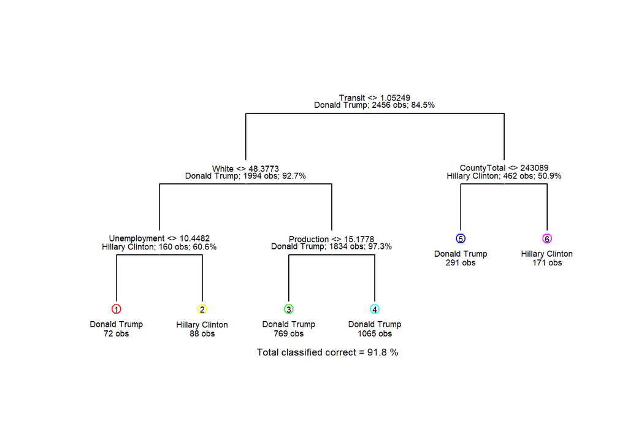

17. From the summary of the logistic regression we can see that the following features are significant: `Men`, `White`, `Citizen`, `Income`, `IncomePerCap`, `IncomePerCapErr`, `Professional`, `Service`, `Production`, `Drive`, `Carpool`, `WorkAtHome`, `MeanCommute`, `Empolyed`, `PrivateWork`, `FamiltyWork` and `Unemployement`. Most of the features used in the tree method is also in this list, such as `White`, `Production`, `Unemployement`. The training error is 0.0704 and the testing error is 0.0634.
18. The optimal value of $\lambda$ is $5 \times 10^{-4}$. The training error is 0.06962541 and the test error is 0.06504065. And a full records table is shown below.

|  | train.error | test.error |
| --- | --- | --- |
| tree | 0.0822500 | 0.0634146 |
| logistic | 0.0704397 | 0.0634146 |
| lasso | 0.0696254 | 0.0650407 |

19. From the plot and get the AUC value we can get that Lasso regression methods has the largest AUC, which implies Lasso regression is a better model than the other two.

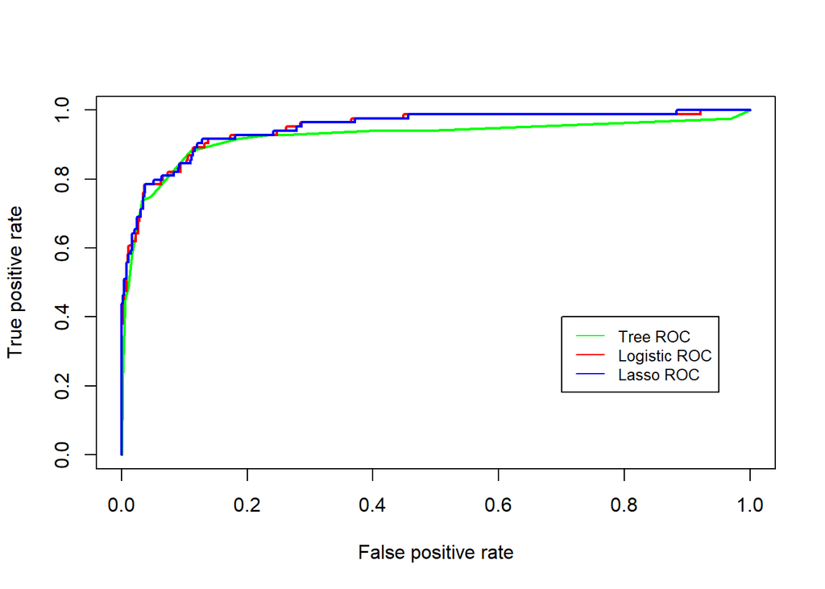

### Taking it further

20. In this question, First I’m going to explore the classification using principle components with logistic regression. Then I’m going to try using random forest and boosting on the original data to get models and see how they behaves. And we’ll set another record matrix to save these models’ training and testing error.

#### Logistic Regression Using Principle Components

From the PVE plot produced earlier in the report, we see that the cumPVE explains 90% of the variance at about 15 PCs. So I’m using the first 15 PCs to create a logistic regression model. We first combine the 15 PCs with the county_winner using the methods above, and split the data set into training and testing sets using the same separating index above. Then perform the logistic regression using `glm()` function.  
This time we still get a warning of fitted probability numerically 0 or 1 occurred, this implies this model is still tend to overfitting. Maybe we need to reduce the number of PC using, but too few PC will lead to a greater bias, so let’s stick to 15 PCs for now. The summary of the logistic regression and the training and test error of this model is shown below. The training error is 0.0814332 and the testing error is 0.06341463. We surprisingly found that the testing error is identical with the logistic regression model with the original features.

```
##
## Call:
## glm(formula = candidate ~ ., family = "binomial", data = pc_trn)
##
## Deviance Residuals:
##     Min       1Q   Median       3Q      Max
## -4.5410  -0.3337  -0.1656  -0.0752   3.3385
##
## Coefficients:
##              Estimate Std. Error z value Pr(>|z|)
## (Intercept) -2.731272   0.122911 -22.222  < 2e-16 ***
## PC1          0.187992   0.036126   5.204 1.95e-07 ***
## PC2         -1.267480   0.072954 -17.374  < 2e-16 ***
## PC3         -0.785680   0.064430 -12.194  < 2e-16 ***
## PC4         -0.197912   0.077028  -2.569  0.01019 *
## PC5         -0.036135   0.085578  -0.422  0.67285
## PC6         -0.572707   0.118613  -4.828 1.38e-06 ***
## PC7          0.619346   0.103088   6.008 1.88e-09 ***
## PC8         -0.562192   0.107760  -5.217 1.82e-07 ***
## PC9         -0.119262   0.101919  -1.170  0.24193
## PC10        -0.522285   0.100384  -5.203 1.96e-07 ***
## PC11         0.375726   0.143118   2.625  0.00866 **
## PC12         0.459063   0.119989   3.826  0.00013 ***
## PC13         0.441204   0.155984   2.829  0.00468 **
## PC14        -0.002134   0.119308  -0.018  0.98573
## PC15        -1.504655   0.162399  -9.265  < 2e-16 ***
## ---
## Signif. codes:  0 '***' 0.001 '**' 0.01 '*' 0.05 '.' 0.1 ' ' 1
##
## (Dispersion parameter for binomial family taken to be 1)
##
##     Null deviance: 2119.6  on 2455  degrees of freedom
## Residual deviance: 1036.6  on 2440  degrees of freedom
## AIC: 1068.6
##
## Number of Fisher Scoring iterations: 7
```

| pc_glm_train_err | pc_glm_test_err |
| --- | --- |
| 0.0814332 | 0.0634146 |

However when we look into the ROC curve and AUC value, we find the AUC value to be 0.9520671, which is larger than all of the three models above, suggesting this model would give as a more accurate predict on testing data sets.

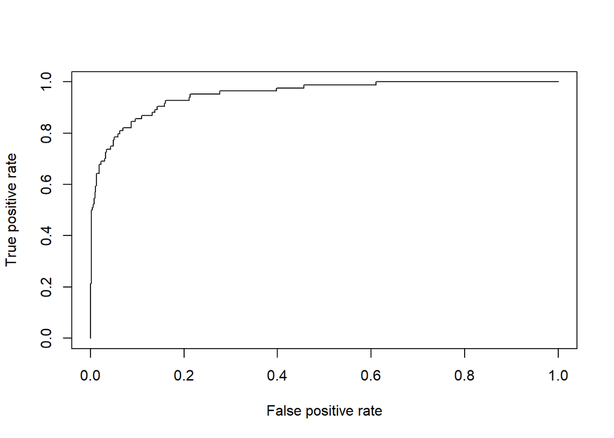

#### Random Forest and Boosting

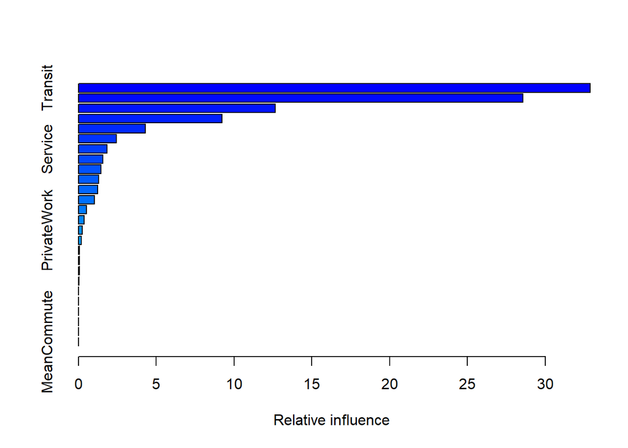

|  | rel.inf |
| --- | --- |
| Transit | 32.879571 |
| White | 28.558197 |
| CountyTotal | 12.651658 |
| Minority | 9.227983 |
| Professional | 4.306322 |
| Employed | 2.445542 |

```
##
## Call:
##  randomForest(formula = candidate ~ ., data = trn.cl, importance = TRUE)
##                Type of random forest: classification
##                      Number of trees: 500
## No. of variables tried at each split: 5
##
##         OOB estimate of  error rate: 5.7%
## Confusion matrix:
##                 Donald Trump Hillary Clinton class.error
## Donald Trump            2037              38  0.01831325
## Hillary Clinton          102             279  0.26771654
```

|  | train.error | test.error |
| --- | --- | --- |
| pc_logis | 0.0814332 | 0.0634146 |
| boosting | 0.0618893 | 0.0650407 |
| random forest | 0.0570000 | 0.0439024 |